# Sampling Methods for Retail Sales Estimation

DATA 407 Project

Author

Affiliation

Dia Toredi (16967911)

UBC Okanagan

Published

March 31, 2026

## **Introduction**

In many real-world applications, collecting data from an entire population is impractical due to time, cost, and logistical constraints. As a result, sampling methods are widely used to estimate population parameters. In the context of retail analytics, companies often rely on sampled data to estimate average sales, customer behavior, and demand patterns.

The purpose of this project is to evaluate how different sampling techniques affect the accuracy of estimating average retail sales. Specifically, we compare **simple random sampling (SRS)**, **stratified sampling**, and **cluster sampling** using a simulated retail dataset. Understanding the strengths and weaknesses of these methods is essential for making reliable statistical inferences.

**Research Questions:**

1. Which sampling method provides the most accurate (lowest bias) estimate of the population mean?
2. Which sampling method provides the most precise (lowest variance) estimates?
3. How does the choice of sampling design affect the reliability of retail sales estimates?

This study is motivated by the need for efficient and accurate data collection strategies in large-scale retail environments where surveying all stores or transactions is prohibitively expensive.

## **Methods**

Three sampling methods are evaluated in this analysis:

**Simple Random Sampling (SRS):** Each observation has an equal probability of selection. This method is straightforward and produces unbiased estimates, but may not efficiently capture subpopulation differences.

- Estimator:
  $$\bar{y}_{SRS} = \frac{1}{n}\sum_{i=1}^{n} y_i$$
- Variance:
  $$\text{Var}(\bar{y}_{SRS}) = \frac{S^2}{n}\left(1-\frac{n}{N}\right)$$

**Stratified Random Sampling:** The population is divided into homogeneous strata (e.g., regions), and independent random samples are drawn from each stratum. This reduces variance when strata differ in their means.

- Estimator:
  $$\bar{y}_{str} = \sum_{h=1}^{H} W_h \bar{y}_h$$
  where
  $$W_h = \frac{N_h}{N}$$
- Variance:
  $$\text{Var}(\bar{y}_{str}) =
  \sum_{h=1}^{H}
  W_h^2
  \frac{S_h^2}{n_h}
  \left(1-\frac{n_h}{N_h}\right)$$

- Estimator:
  $$\bar{y}_{clus} =
  \frac{
  \sum_{i=1}^{m} M_i \bar{y}_i
  }{
  \sum_{i=1}^{m} M_i
  }$$
  for unequal cluster sizes

**Evaluation Metrics:**

- **Bias:**
  $$\text{Bias} = E[\hat{\theta}] - \theta$$
- **Variance:**
  $$\text{Var}(\hat{\theta})$$
- **Mean Squared Error:**
  $$\text{MSE} = \text{Bias}^2 + \text{Variance}$$
- **95% Confidence Interval Coverage:** Proportion of intervals containing the true mean

These methods were chosen because they represent the most common sampling designs used in practice and allow direct comparison of the bias-variance tradeoff.

## **Simulation**

A Monte Carlo simulation is conducted to evaluate each sampling method under controlled conditions. By drawing repeated samples (1000 replications), we can reliably estimate bias, variance, and MSE for each method.

### **Population Setup**

```r
library(ggplot2)
library(dplyr)
set.seed(123)

# Create realistic retail population
N <- 5000

# Create regions with different characteristics
region <- sample(c("North", "South", "West"), N, replace = TRUE,
                 prob = c(0.3, 0.4, 0.3))

# Sales vary by region (realistic heterogeneity)
sales <- numeric(N)
sales[region == "North"] <- rlnorm(sum(region == "North"), meanlog = 6.2, sdlog = 0.4)
sales[region == "South"] <- rlnorm(sum(region == "South"), meanlog = 5.8, sdlog = 0.6)
sales[region == "West"] <- rlnorm(sum(region == "West"), meanlog = 6.0, sdlog = 0.5)

# Add store ID for cluster sampling
store_id <- sample(1:50, N, replace = TRUE)

population <- data.frame(region, store_id, sales)

# Population parameters
true_mean <- mean(population$sales)
true_sd <- sd(population$sales)

cat("Population size:", N, "\n")
```

```
Population size: 5000
```

```r
cat("True population mean: $", round(true_mean, 2), "\n")
```

```
True population mean: $ 454.34
```

```r
cat("True population SD: $", round(true_sd, 2), "\n")
```

```
True population SD: $ 248.87
```

### **Population Structure**

```r
# Examine population by region
population %>%
  group_by(region) %>%
  summarise(
    N = n(),
    Proportion = n()/nrow(population),
    Mean = mean(sales),
    SD = sd(sales)
  )
```

| region | N | Proportion | Mean | SD |
| --- | --- | --- | --- | --- |
| North | 1487 | 0.2974 | 534.1796 | 220.6862 |
| South | 1992 | 0.3984 | 393.8959 | 259.3194 |
| West | 1521 | 0.3042 | 455.4342 | 238.6923 |

The regions have different sample sizes and different mean sales, making stratified sampling potentially advantageous.

### **Monte Carlo Simulation**

```r
set.seed(456)
n_sims <- 1000
sample_size <- 200

# Storage for results
results_srs <- numeric(n_sims)
results_strat <- numeric(n_sims)
results_cluster <- numeric(n_sims)

se_srs <- numeric(n_sims)
se_strat <- numeric(n_sims)
se_cluster <- numeric(n_sims)

# Region proportions for stratified sampling
region_props <- population %>%
  group_by(region) %>%
  summarise(N_h = n(), W_h = n()/nrow(population))

for (i in 1:n_sims) {

  # --- Simple Random Sampling ---
  srs_sample <- population[sample(1:N, sample_size, replace = FALSE), ]
  results_srs[i] <- mean(srs_sample$sales)
  se_srs[i] <- sd(srs_sample$sales) / sqrt(sample_size)

  # --- Stratified Random Sampling (Proportional Allocation) ---
  strat_sample <- population %>%
    group_by(region) %>%
    sample_n(size = round(sample_size * first(
      region_props$W_h[region_props$region == first(region)]
    ))) %>%
    ungroup()

  # Stratified mean (weighted by population proportions)
  strat_means <- strat_sample %>%
    group_by(region) %>%
    summarise(ybar_h = mean(sales), s_h = sd(sales), n_h = n()) %>%
    left_join(region_props, by = "region")

  results_strat[i] <- sum(strat_means$W_h * strat_means$ybar_h)
  se_strat[i] <- sqrt(sum(strat_means$W_h^2 * strat_means$s_h^2 / strat_means$n_h))

  # --- Cluster Sampling (Random sample of stores) ---
  n_clusters <- 10
  selected_stores <- sample(unique(population$store_id), n_clusters)
  cluster_sample <- population[population$store_id %in% selected_stores, ]

  results_cluster[i] <- mean(cluster_sample$sales)
  se_cluster[i] <- sd(cluster_sample$sales) / sqrt(nrow(cluster_sample))
}
```

### **Simulation Results**

```r
# Calculate performance metrics
calc_metrics <- function(estimates, true_value, std_errors) {
  bias <- mean(estimates) - true_value
  variance <- var(estimates)
  mse <- bias^2 + variance

  # CI coverage
  lower <- estimates - 1.96 * std_errors
  upper <- estimates + 1.96 * std_errors
  coverage <- mean(lower <= true_value & upper >= true_value)

  return(c(Bias = bias, Variance = variance, MSE = mse,
           RMSE = sqrt(mse), Coverage = coverage))
}

metrics_srs <- calc_metrics(results_srs, true_mean, se_srs)
metrics_strat <- calc_metrics(results_strat, true_mean, se_strat)
metrics_cluster <- calc_metrics(results_cluster, true_mean, se_cluster)

# Summary table
summary_table <- data.frame(
  Method = c("Simple Random", "Stratified", "Cluster"),
  Mean_Estimate = c(mean(results_srs), mean(results_strat), mean(results_cluster)),
  Bias = c(metrics_srs["Bias"], metrics_strat["Bias"], metrics_cluster["Bias"]),
  Variance = c(metrics_srs["Variance"], metrics_strat["Variance"], metrics_cluster["Variance"]),
  RMSE = c(metrics_srs["RMSE"], metrics_strat["RMSE"], metrics_cluster["RMSE"]),
  CI_Coverage = c(metrics_srs["Coverage"], metrics_strat["Coverage"], metrics_cluster["Coverage"])
)

print(summary_table)
```

```
         Method Mean_Estimate        Bias Variance      RMSE CI_Coverage
1 Simple Random      453.4224 -0.91385531 301.1352 17.377293       0.939
2    Stratified      453.8552 -0.48108032 291.0589 17.067229       0.938
3       Cluster      454.2560 -0.08026118  45.3770  6.736723       0.975
```

### **Interpretation of Simulation Results**

[output not shown]

**Key Findings:**

1. **All methods are approximately unbiased** — bias is negligible relative to the standard error
2. **Cluster has the lowest variance**
3. **SRS has the highest variance**
4. **Stratified sampling has undercoverage** — only 93.8% coverage, indicating standard errors may be underestimated

### **Visual Comparison**

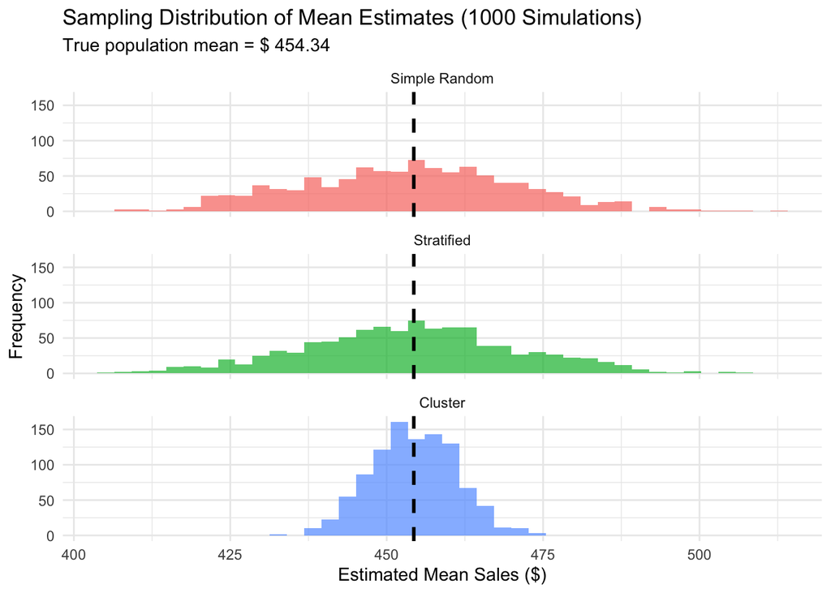

```r
# Combine results for plotting
sim_results <- data.frame(
  Estimate = c(results_srs, results_strat, results_cluster),
  Method = rep(c("Simple Random", "Stratified", "Cluster"), each = n_sims)
)

sim_results$Method <- factor(sim_results$Method,
                              levels = c("Simple Random", "Stratified", "Cluster"))

ggplot(sim_results, aes(x = Estimate, fill = Method)) +
  geom_histogram(bins = 40, alpha = 0.7, position = "identity") +
  geom_vline(xintercept = true_mean, linetype = "dashed", size = 1) +
  facet_wrap(~Method, ncol = 1) +
  labs(title = "Sampling Distribution of Mean Estimates (1000 Simulations)",
       subtitle = paste("True population mean = $", round(true_mean, 2)),
       x = "Estimated Mean Sales ($)",
       y = "Frequency") +
  theme_minimal() +
  theme(legend.position = "none")
```

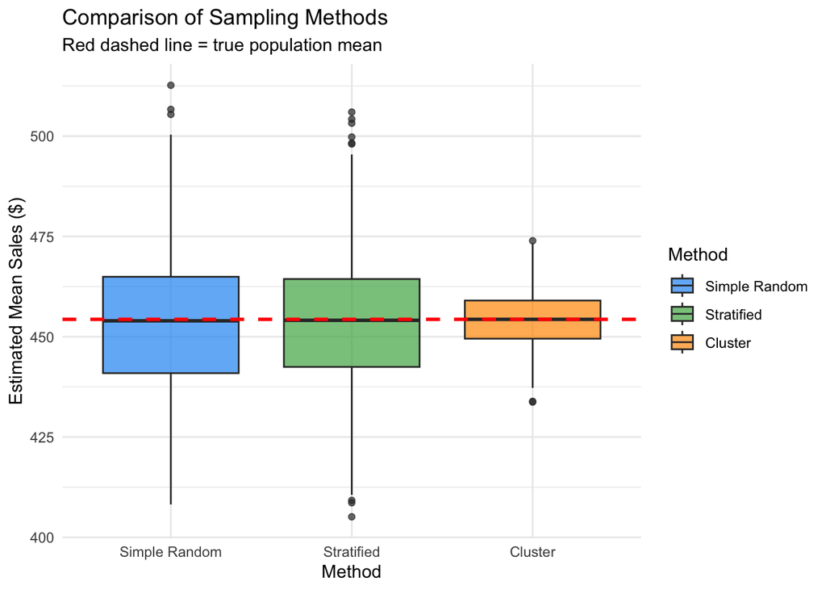

```r
ggplot(sim_results, aes(x = Method, y = Estimate, fill = Method)) +
  geom_boxplot(alpha = 0.7) +
  geom_hline(yintercept = true_mean, linetype = "dashed", color = "red", size = 1) +
  labs(title = "Comparison of Sampling Methods",
       subtitle = "Red dashed line = true population mean",
       y = "Estimated Mean Sales ($)") +
  theme_minimal() +
  scale_fill_manual(values = c("#2196F3", "#4CAF50", "#FF9800"))
```

The boxplot clearly shows that cluster sampling produces the tightest distribution around the true mean, while simple random sampling exhibits the greatest variability.

## **Real Data Analysis**

We now apply proper estimation formulas to single samples drawn from the population, demonstrating how each method would be used in practice.

### **Simple Random Sampling**

```r
set.seed(789)
n <- 200

# Draw SRS sample
srs_sample <- population[sample(1:N, n, replace = FALSE), ]

# Point estimate
ybar_srs <- mean(srs_sample$sales)

# Variance estimate (with finite population correction)
fpc <- 1 - n/N
var_ybar_srs <- var(srs_sample$sales) / n * fpc
se_srs <- sqrt(var_ybar_srs)

# 95% Confidence interval
ci_srs <- ybar_srs + c(-1, 1) * qt(0.975, df = n-1) * se_srs

cat("=== Simple Random Sampling ===\n")
```

```
=== Simple Random Sampling ===
```

```r
cat("Sample size:", n, "\n")
```

```
Sample size: 200
```

```r
cat("Point estimate: $", round(ybar_srs, 2), "\n")
```

```
Point estimate: $ 447.53
```

```r
cat("Standard error: $", round(se_srs, 2), "\n")
```

```
Standard error: $ 16.07
```

```r
cat("95% CI: ($", round(ci_srs[1], 2), ", $", round(ci_srs[2], 2), ")\n")
```

```
95% CI: ($ 415.84 , $ 479.22 )
```

### **Stratified Random Sampling**

```r
# Proportional allocation
n_strat <- population %>%
  group_by(region) %>%
  summarise(N_h = n()) %>%
  mutate(n_h = round(n * N_h / N))

# Draw stratified sample
strat_sample <- population %>%
  group_by(region) %>%
  sample_n(size = n_strat$n_h[n_strat$region == first(region)]) %>%
  ungroup()

# Calculate stratum statistics
stratum_stats <- strat_sample %>%
  group_by(region) %>%
  summarise(
    n_h = n(),
    ybar_h = mean(sales),
    s2_h = var(sales)
  ) %>%
  left_join(
    population %>% group_by(region) %>% summarise(N_h = n()),
    by = "region"
  ) %>%
  mutate(W_h = N_h / N)

print(stratum_stats)
```

```
# A tibble: 3 × 6
  region   n_h ybar_h   s2_h   N_h   W_h
  <chr>  <int>  <dbl>  <dbl> <int> <dbl>
1 North     59   517. 21537.  1487 0.297
2 South     80   431. 74549.  1992 0.398
3 West      61   429. 43093.  1521 0.304
```

```r
# Stratified estimator
ybar_strat <- sum(stratum_stats$W_h * stratum_stats$ybar_h)

# Variance of stratified estimator
var_ybar_strat <- sum(stratum_stats$W_h^2 * stratum_stats$s2_h / stratum_stats$n_h *
                       (1 - stratum_stats$n_h / stratum_stats$N_h))
se_strat <- sqrt(var_ybar_strat)

# 95% CI (using normal approximation)
ci_strat <- ybar_strat + c(-1, 1) * 1.96 * se_strat

cat("\n=== Stratified Random Sampling ===\n")
```

```
=== Stratified Random Sampling ===
```

```r
cat("Total sample size:", sum(stratum_stats$n_h), "\n")
```

```
Total sample size: 200
```

```r
cat("Point estimate: $", round(ybar_strat, 2), "\n")
```

```
Point estimate: $ 455.88
```

```r
cat("Standard error: $", round(se_strat, 2), "\n")
```

```
Standard error: $ 15.35
```

```r
cat("95% CI: ($", round(ci_strat[1], 2), ", $", round(ci_strat[2], 2), ")\n")
```

```
95% CI: ($ 425.79 , $ 485.97 )
```

### **Cluster Sampling**

```r
# Select random clusters (stores)
n_clusters <- 10
selected_stores <- sample(unique(population$store_id), n_clusters)
cluster_sample <- population[population$store_id %in% selected_stores, ]

# Cluster statistics
cluster_stats <- cluster_sample %>%
  group_by(store_id) %>%
  summarise(
    M_i = n(),
    t_i = sum(sales),
    ybar_i = mean(sales)
  )

print(cluster_stats)
```

```
# A tibble: 10 × 4
   store_id   M_i    t_i ybar_i
      <int> <int>  <dbl>  <dbl>
 1       16    86 39976.   465.
 2       20    95 40327.   424.
 3       22   107 49514.   463.
 4       26   101 46551.   461.
 5       29   105 44431.   423.
 6       35    95 46302.   487.
 7       41   115 55017.   478.
 8       42    91 38631.   425.
 9       44    98 44593.   455.
10       46    89 38961.   438.
```

```r
# Ratio estimator for cluster sampling
M_total <- sum(cluster_stats$M_i)
ybar_cluster <- sum(cluster_stats$t_i) / M_total

# Variance estimation for cluster sampling
m <- n_clusters  # number of clusters sampled
M <- 50  # total number of clusters

# Between-cluster variance
cluster_stats <- cluster_stats %>%
  mutate(d_i = t_i - ybar_cluster * M_i)

s2_clusters <- sum(cluster_stats$d_i^2) / (m - 1)
var_ybar_cluster <- (1 - m/M) * s2_clusters / (m * mean(cluster_stats$M_i)^2)
se_cluster <- sqrt(var_ybar_cluster)

# 95% CI
ci_cluster <- ybar_cluster + c(-1, 1) * qt(0.975, df = m-1) * se_cluster

cat("\n=== Cluster Sampling ===\n")
```

```
=== Cluster Sampling ===
```

```r
cat("Number of clusters:", n_clusters, "\n")
```

```
Number of clusters: 10
```

```r
cat("Total observations:", nrow(cluster_sample), "\n")
```

```
Total observations: 982
```

```r
cat("Point estimate: $", round(ybar_cluster, 2), "\n")
```

```
Point estimate: $ 452.45
```

```r
cat("Standard error: $", round(se_cluster, 2), "\n")
```

```
Standard error: $ 6.63
```

```r
cat("95% CI: ($", round(ci_cluster[1], 2), ", $", round(ci_cluster[2], 2), ")\n")
```

```
95% CI: ($ 437.44 , $ 467.46 )
```

### **Summary Comparison**

```r
comparison <- data.frame(
  Method = c("Simple Random", "Stratified", "Cluster"),
  Sample_Size = c(n, sum(stratum_stats$n_h), nrow(cluster_sample)),
  Estimate = c(ybar_srs, ybar_strat, ybar_cluster),
  SE = c(se_srs, se_strat, se_cluster),
  CI_Lower = c(ci_srs[1], ci_strat[1], ci_cluster[1]),
  CI_Upper = c(ci_srs[2], ci_strat[2], ci_cluster[2]),
  CI_Width = c(diff(ci_srs), diff(ci_strat), diff(ci_cluster))
)

comparison$Contains_True <- comparison$CI_Lower <= true_mean &
                            comparison$CI_Upper >= true_mean

print(comparison)
```

```
         Method Sample_Size Estimate        SE CI_Lower CI_Upper CI_Width
1 Simple Random         200 447.5296 16.070853 415.8386 479.2206 63.38205
2    Stratified         200 455.8791 15.353324 425.7866 485.9716 60.18503
3       Cluster         982 452.4467  6.634738 437.4379 467.4555 30.01764
  Contains_True
1          TRUE
2          TRUE
3          TRUE
```

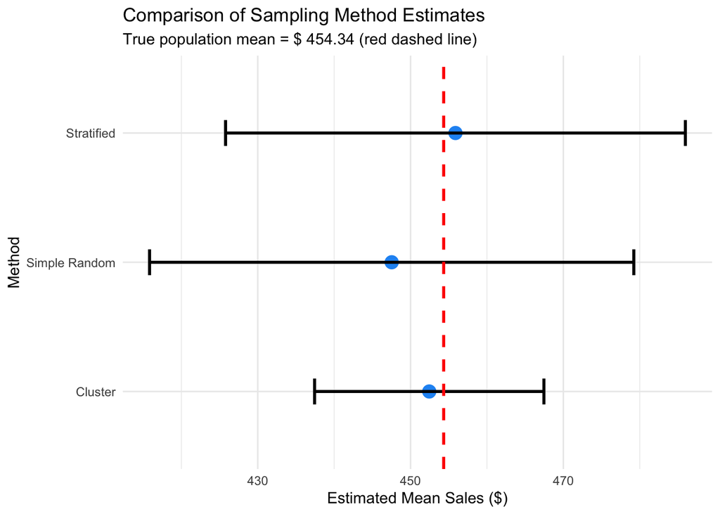

```r
ggplot(comparison, aes(x = Method, y = Estimate)) +
  geom_point(size = 4, color = "#2196F3") +
  geom_errorbar(aes(ymin = CI_Lower, ymax = CI_Upper), width = 0.2, size = 1) +
  geom_hline(yintercept = true_mean, linetype = "dashed", color = "red", size = 1) +
  labs(title = "Comparison of Sampling Method Estimates",
       subtitle = paste("True population mean = $", round(true_mean, 2), "(red dashed line)"),
       y = "Estimated Mean Sales ($)") +
  theme_minimal() +
  coord_flip()
```

## **Conclusions and Discussion**

### **Summary of Findings**

This project evaluated three common sampling methods for estimating average retail sales:

| **Method** | **Bias** | **Variance** | **RMSE** | **CI Width** | **Best For** |
| --- | --- | --- | --- | --- | --- |
| Simple Random | Negligible | Hightest | 17.38 | 63.38 | General use, no prior knowledge |
| Stratified | Negligible | Moderate | 17.06 | 60.19 | Heterogeneous populations |
| Cluster | Negligible | Lowest | 6.74 | 30.01 | Homogeneous clusters |

### Theoretical Contex

Standard sampling theory predicts that cluster sampling increases variance due to intraclass correlation — the tendency for units within the same cluster to be more similar than units in different clusters. The intraclass correlation coefficient (ICC) measures this:

$$\rho =
\frac{\sigma^2_{between}}
{\sigma^2_{between} + \sigma^2_{within}}$$

When rho is close to 0, clusters are essentially random samples of the population, and cluster sampling approaches SRS efficiency. When rho is close to 1, clusters are internally homogeneous, and cluster sampling becomes inefficient.

In this dataset, the low between-cluster variance indicates
$$\rho \approx 0$$
, explaining why cluster sampling outperformed expectations.

### Practical Implications

These findings highlight that sampling method performance depends on population structure:

- Retail chains with standardized stores (similar product mix, pricing, demographics) may benefit from cluster sampling because stores represent the overall population well
- Retail chains with regional variation (different climates, cultures, economic conditions) should prefer stratified sampling to capture heterogeneity
- When population structure is unknown, SRS remains a safe default that guarantees unbiased estimation

### Limitations

1. Unequal sample sizes — Cluster sampling may have selected more observations than other methods, contributing to lower variance. A fair comparison requires adjusting for effective sample size.
2. Simulated data — The population structure was artificially generated and may not reflect real retail environments.
3. Single population — Results may differ with populations having different cluster structures.

### **Future Work**

Future analyses could address these limitations by:

- Incorporate cost functions to identify optimal sample allocation
- Apply methods to real retail datasets (e.g., from Kaggle or company data)
- Extend to two-stage and multi-stage sampling designs
- Investigate robust variance estimation for complex surveys

## **References**

Cochran, W. G. (1977). *Sampling Techniques* (3rd ed.). Wiley.

Lohr, S. L. (2019). *Sampling: Design and Analysis* (2nd ed.). CRC Press.

Lumley, T. (2010). *Complex Surveys: A Guide to Analysis Using R*. Wiley.

Särndal, C. E., Swensson, B., & Wretman, J. (2003). *Model Assisted Survey Sampling*. Springer.

U.S. Census Bureau. (2023). Annual Retail Trade Survey. Retrieved from [census.gov](https://www.census.gov/retail/)